# Topic Modelling

# Objective

In this notebook, I will perform topic modelling on the OKCupid dataset. The dataset contains information about users and their responses to questions. I will focus on “About Me” and “What I do on Friday night” columns to extract topics. The implementation is based on the paper “[Structural Topic Models for Open-Ended Survey Responses](https://www.jstor.org/stable/24363543)” by Roberts et al. (2014) and the R package [stm](https://cran.r-project.org/web/packages/stm/vignettes/stmVignette.pdf).

# Preprocessing

First step, load libraries

```r
library(tidyverse)
library(stm)
```

Second step, load the dataset

```r
# load the zip file and extract the csv file and save it as df
df <- unzip("data.csv.zip", "data.csv") %>%
  read_csv()
# mutate a new column called ID which is the row number
df <- df %>%
  mutate(ID = row_number())

# replace the space with underscore in the column names
names(df) <- str_replace_all(names(df), " ", "_")

# column names to lower case
names(df) <- tolower(names(df))
```

# Topic Modelling - About Me

Now, I will perform topic modelling on the “About Me” column. I will start by preprocessing the text data.

## Preprocessing

```r
processed <- textProcessor(df$my_self_summary, metadata = df)
```

```
Building corpus...
Converting to Lower Case...
Removing punctuation...
Removing stopwords...
Removing numbers...
Stemming...
Creating Output...
```

```r
out <- prepDocuments(processed$documents, processed$vocab, processed$meta)
```

```
Removing 20106 of 33957 terms (20106 of 795437 tokens) due to frequency
Removing 17 Documents with No Words
Your corpus now has 15198 documents, 13851 terms and 775331 tokens.
```

```r
docs <- out$documents
vocab <- out$vocab
meta  <-out$meta
```

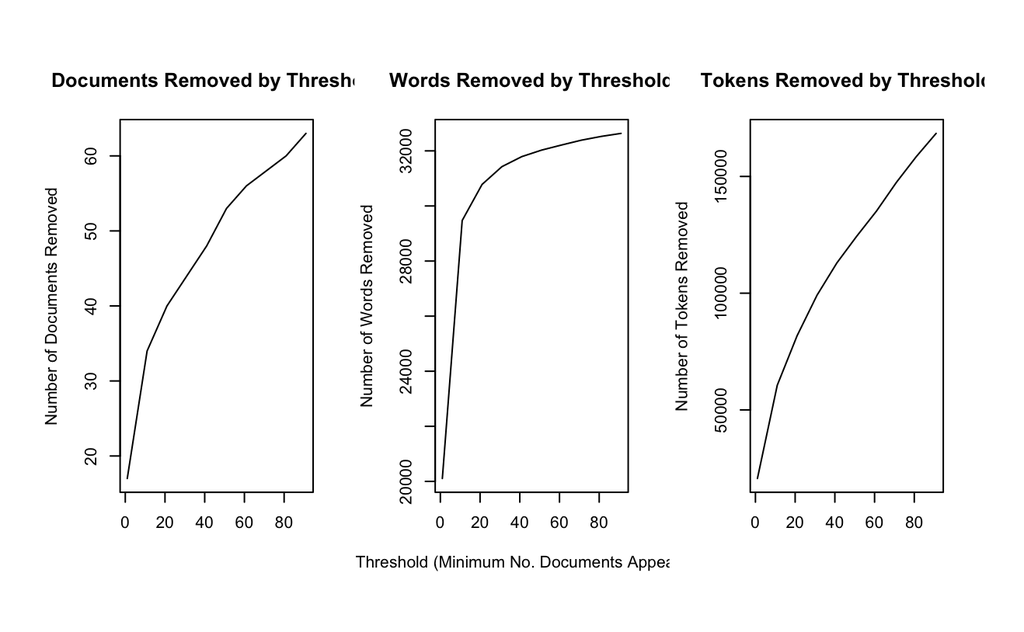

```r
plotRemoved(processed$documents, lower.thresh = seq(1, 100, by = 10))
```

```r
out <- prepDocuments(processed$documents, processed$vocab, processed$meta, lower.thresh = 20)
```

```
Removing 30708 of 33957 terms (77646 of 795437 tokens) due to frequency
Removing 40 Documents with No Words
Your corpus now has 15175 documents, 3249 terms and 717791 tokens.
```

```r
docs <- out$documents
vocab <- out$vocab
meta  <-out$meta
```

## Selecting the k

```r
# storage <- searchK(out$documents, out$vocab, K = c(3: 10), prevalence =~ belief, data = meta)
```

```r
# plot(x = storage$results$semcoh, y =  storage$results$exclus,
#      xlab = "Semantic Coherence", ylab = "Exclusivity")
# text(storage$results$semcoh, storage$results$exclus,labels=storage$results$K, cex= 0.5, pos=3)
```

## Examining k = 5

```r
prev5<-stm(documents = out$documents, vocab = out$vocab, prevalence =~ belief, K = 5, max.em.its = 75, data = out$meta, init.type = "Spectral")
```

```r
summary(prev5)
```

```
A topic model with 5 topics, 15175 documents and a 3249 word dictionary.
Topic 1 Top Words:
     Highest Prob: enjoy, good, also, around, area, world, place
     FREX: girl, bike, least, teach, around, creat, place
     Lift: filter, -go, stair, starbuck, writer, breaker, analyt
     Score: enjoy, good, also, area, around, place, world
Topic 2 Top Words:
     Highest Prob: time, new, look, person, ive, meet, tri
     FREX: meet, person, beach, pretti, heart, general, cook
     Lift: blah, holiday, land, sea, indic, pound, flip
     Score: blah, look, new, person, time, meet, pretti
Topic 3 Top Words:
     Highest Prob: love, peopl, thing, friend, can, work, live
     FREX: love, friend, word, day, career, tend, perfect
     Lift: yep, lame, vast, lead, hint, perfect, disclaim
     Score: love, friend, peopl, work, can, thing, someon
Topic 4 Top Words:
     Highest Prob: like, life, get, dont, year, one, want
     FREX: man, way, relationship, sound, get, without, like
     Lift: chosen, man, histor, freak, cow, nearbi, over
     Score: like, life, get, year, dont, one, think
Topic 5 Top Words:
     Highest Prob: just, know, make, fun, will, take, alway
     FREX: coast, end, may, found, smile, soul, genuin
     Lift: cooler, found, task, knock, texa, juic, progress
     Score: just, know, take, will, alway, fun, interest
```

```r
# get remaining ID
remaining_id <- meta$id

# use remaining_id to subset df by ID
df_about_me <- df %>%
  filter(id %in% remaining_id)

# check dimensions
dim(df_about_me)
```

```
[1] 15175    25
```

```r
thought1 <- findThoughts(prev5, texts = df_about_me$my_self_summary, topic = 1, n = 3)
thought2 <- findThoughts(prev5, texts = df_about_me$my_self_summary, topic = 2, n = 3)
thought3 <- findThoughts(prev5, texts = df_about_me$my_self_summary, topic = 3, n = 3)
thought4 <- findThoughts(prev5, texts = df_about_me$my_self_summary, topic = 4, n = 3)
thought5 <- findThoughts(prev5, texts = df_about_me$my_self_summary, topic = 5, n = 3)
```

```r
thought1
```

```
 Topic 1:
     i enjoy emersing myself in learning new things and expanding my knowledge about the world we live in. whether it's reading a book, taking a class or just having an intellectually stimulating conversation with someone over coffee, i always strive to learn more. i enjoy learning and discussing ab…
    hi. i'm joel.  i'm a creative person who enjoys city adventures, thoughtful debauchery, and intellectual challenges.  a few quick classifications: i'm a myers-briggs intp (the "architect", so interested in the forest i keep running head-first into these crazy trees), a feminist, and a secular hu…
    helping those in need is my interest..it makes me happy when people feel better after a talk or anything in life experience shared. working on a school environment allows me to contribute by helping our students succeed through education and mentorship.  places travelled to are spain, italy, fra…
```

```r
thought2
```

```
 Topic 2:
     i'm a spanish (from spain) 32-year-old not-woman-but-girl wishing i still lived in san francisco.  people say i'm a very creative person, easy to talk to, outgoing but introverted (that's a weird paradox, i know, tell me about it). sometimes i talk a lot, sometimes not at all. depends on whethe…
    giving, intelligent, active man seeks beautiful, affectionate, caring woman to pamper and please! i am looking for a woman who is beautiful inside and out and who is kind, emotionally giving, and wishes to be cherished. right now i am open to many different types of relationships - short term or…
    6 ft 1 in 165 lb white professional non-smoker, drug free, disease free. i'm recently divorced after a 29 year marriage, but not to worry, no baggage or "drama". i love hiking, bicycling, long walks, working out, traveling, photography, humor, books, music & the arts, photography, ballroom danci…
```

```r
thought3
```

```
 Topic 3:
     it's now time to deconstruct the entirety of my persona and put it back together in a concise, very generalized list form.  i am's:  - i'm kind - i'm creative - i'm a very social - i'm loyal - i'm musical - i'm optimistic - i'm knowledgeable about the things i love - i'm a cutthroat skeptic - i…
    i am queer and i like to fuck with gender, sexuality, and kink. i am sex-positive and love to express my sexuality. i am only shy when i first meet someone. i want someone who can reel me in and hold me there. i usually don't do well with subs or sparkle ponies. i think touch is amazing. i reall…
    i'm a country girl who loves animals and who is looking for that cowboy of mine to sweep me off my feet and show me what a real man is. i have a weakness for cowboys, firemen, kissing ;) and older, taller guys up to 10 years my age. i like to be outdoors rather than indoors. i love to travel, bu…
```

```r
thought4
```

```
 Topic 4:
     hello!  life is quite the adventure! i'm looking for someone who is just raring to go and who will say, "when?" not "maybe." someone who possesses joie de vivre. you must be confident (not arrogant) and be comfortable in your own skin. i've come to the realization that while a person can be gre…
    summertime, and the livin' is easy..  i am a simple, down to earth guy, i like old cars, hot women,(this is subjective for me and has less to do with physical appearances and more to do with what i consider 'hot' i.e. confidence, kindness a sense of humor and a strong sex drive) good food, good …
    read this first: i'm in a happy relationship and am just looking for friends. that being said, however, i really get excited about meeting new people and i heartily encourage you to message me if you think we'd get along.  i love hiking, camping, backpacking, and exploring outdoors. i'm always l…
```

```r
thought5
```

```
 Topic 5:
     i have a girlfriend. i am just on here to see changes and conversation to make friends  i am josh, 20, i am a very outgoing person, who likes to have fun and a good time. i love going to baseball games, watching movies, bowling, and listening to music, i also like hiking, just hanging out, i lo…
    self summary, i hate these. what are you supposed to say, how great i think i am and why everyone should wanna know me? i hate posing for pictures too, it's so fake i have no idea what i am supposed to be doing, just take a quick picture and get the real me if you can, much more natural. hey i k…
    i am honest, loyal and can be quite philosophical at times. and i love to have fun and spend time with the people i care about most.  i'm great at listening, inspiring and analyzing. my friends mean the world to me and i am always willing to stand guard for them or charge into battle at their si…
```

## Examining k = 6

```r
prev6<-stm(documents = out$documents, vocab = out$vocab, prevalence =~ belief, K = 6, max.em.its = 75, data = out$meta, init.type = "Spectral")
```

```r
summary(prev6)
```

```
A topic model with 6 topics, 15175 documents and a 3249 word dictionary.
Topic 1 Top Words:
     Highest Prob: work, live, can, peopl, one, think, lot
     FREX: eat, adventur, york, join, stori, project, alon
     Lift: filter, solid, gregari, gift, enthusiasm, tomorrow, subject
     Score: work, can, live, one, think, interest, lot
Topic 2 Top Words:
     Highest Prob: new, look, enjoy, san, movi, anyth, meet
     FREX: san, explor, bike, cant, weekend, anyth, look
     Lift: blah, rugbi, foodi, elementari, ship, weekend, diego
     Score: new, blah, look, enjoy, san, school, hike
Topic 3 Top Words:
     Highest Prob: love, friend, good, year, travel, fun, famili
     FREX: travel, born, francisco, trip, hang, bay, nativ
     Lift: yep, dali, colorado, travel, californian, pit, nativ
     Score: love, friend, travel, year, good, bay, area
Topic 4 Top Words:
     Highest Prob: life, dont, well, read, back, kind, learn
     FREX: creativ, prefer, read, first, may, balanc, theyr
     Lift: chosen, assert, flame, tongu, brigg, facet, aggress
     Score: dont, life, kind, read, back, still, chosen
Topic 5 Top Words:
     Highest Prob: thing, just, time, person, ive, want, will
     FREX: will, need, person, general, give, want, howev
     Lift: cooler, flaw, phone, comedian, will, given, internet
     Score: just, will, thing, person, want, ive, time
Topic 6 Top Words:
     Highest Prob: like, get, make, know, realli, someon, also
     FREX: woman, probabl, face, yet, sinc, get, seek
     Lift: sock, mail, domin, programm, videogam, distract, yeah
     Score: like, get, know, make, realli, play, music
```

```r
# get remaining ID
remaining_id <- meta$id

# use remaining_id to subset df by ID
df_about_me <- df %>%
  filter(id %in% remaining_id)

# check dimensions
dim(df_about_me)
```

```
[1] 15175    25
```

```r
thought1 <- findThoughts(prev6, texts = df_about_me$my_self_summary, topic = 1, n = 3)
thought2 <- findThoughts(prev6, texts = df_about_me$my_self_summary, topic = 2, n = 3)
thought3 <- findThoughts(prev6, texts = df_about_me$my_self_summary, topic = 3, n = 3)
thought4 <- findThoughts(prev6, texts = df_about_me$my_self_summary, topic = 4, n = 3)
thought5 <- findThoughts(prev6, texts = df_about_me$my_self_summary, topic = 5, n = 1)
thought6 <- findThoughts(prev6, texts = df_about_me$my_self_summary, topic = 6, n = 3)
```

```r
thought1
```

```
 Topic 1:
     enclosed you will find all the parts for your new bluetoonist companion mark 2.0. assembly is straight-forward and requires only a minimal set of tools. we recommend a quirky disposition, two brains (left and right, metric), and a medium-sized allen wrench. full instructions on the many functio…
    currently i'm not really looking for anything, but i find the introspective nature of this site to be interesting and i plan on keeping up my profile if only for the questions and the quizzes.  ------------------------------------------------------------  sometimes i think i think too much, but …
    people who know me, know that i take things seriously. but i'm also very creative. art was my life, until i just didn't have the time for it any more. but, i still feel that everything that we encounter with our senses is art. and if everything is art then everything is beautiful. my favoret med…
```

```r
thought2
```

```
 Topic 2:
     i am a san francisco native that loves the city life. i am a social butterfly and am happiest when i am busy. once i was a wallflower, now i am super outgoing and talkative and have found my calling in pr. i enjoy exploring the city and everything it has to offer. from the nightlife to hiking t…
    i love to travel, explore new places and try new things. my philosophy on travel has always been if you have the chance- go. this idea has taken me to a lot of cool places. lately i've been in a central and south america kick- and visited brazil, argentina, costa rica, honduras and guatemala in …
    i recently moved to san francisco from orange county for a new job at a publishing company. i love adventures and traveling and exploring new cultures. i typically work hard on the weekdays and enjoy relaxing and exploring the city on the weekends. every day i learn something new about sf and i …
```

```r
thought3
```

```
 Topic 3:
     i am a down-to-earth guy, born and raised in the bay area, looking for a fun, relaxed, mature, and considerate woman. i enjoy traveling, hiking, being outdoors, film, music, concerts, art, dining out or cooking at home, watching some sports (baseball and football), and most importantly spending…
    simple, outgoing with a splash of sense of humor. born in queens, ny and raised in chicago and san francisco. half chinese and half korean. love exploring, traveling and meeting new people. family first with an open heart for everybody. love the giants and the niners! love most cuisines and love…
    fun loving and smart. i love to laugh and have others laugh with me. i'm even-keeled, upbeat and try to go with the flow. friends and family are my top priority and i am lucky to live close to my family to be able to spend time with them. i'm a sf native (5th generation!) and i love exploring an…
```

```r
thought4
```

```
 Topic 4:
     very important: if you use marijuana or other recreational drugs/substances in any frequency do not read my profile or message me and please leave. fucking serious.  some things you should know:  i'm very kind, but i'm not very nice. i don't take compliments easily. i have an intense and uncomm…
    my name is suzanna. i'm 20, originally from manchester, england. i'm a pretty straight-forward girl. i know english and french, so please, only those languages. if i don't like you, don't expect a reply. if you don't have a picture, do not talk to me. i'll talk to anyone who interests me, if you…
    alright, that last description of myself was terrible. i must have been drunk or something. what are you supposed to write here though? i mean how can i just sum myself up in a little box? are there enough words to truly describe what i am? probably not. i'd like to think that i am intelligent (…
```

```r
thought5
```

```
 Topic 5:
     hello, my name is yuval. i moved to the bay area from israel in 1998 to pursue a career in the high-tech industry. my 'online' dating philosophy is simple - lets go 'offline'. i'd rather meet in person for a coffee or a walk and practically see what happens. if you rather screen/interview guys …
```

```r
thought6
```

```
 Topic 6:
     baby, chad warden is all about the games! i love me some pstriple. anything else is just mad gay. shit- aight- i mean, niggas be talkin' bout that xbox 360. xbox circle? them niggas be thinkin' they so smart. we ain't tryin' to do no geometry! we tryin' to play some games! i mean- xbox 360 don'…
    "i was born a poor black child...." (no, not really.)  what would you like to know?  you know that guy who, when you login to this site, you say "hmm, i wonder if...."? that guy, who might be a total jackass or could be the one? that guy, who is a "(insert # here) %" match, and you can't help bu…
    ehh. for those who must know, i'm very quiet and mild-mannered and all that unattractive jazz, unless i'm lallygagging with friends or in front of a camera. i am currently attending skyline community college and somewhat enjoy it. i'm much more concerned about completing my novel and making the …
```

```r
prep <- estimateEffect(1:6 ~ belief, prev6, meta = meta, uncertainty = "Global")
summary(prep)
```

```
Call:
estimateEffect(formula = 1:6 ~ belief, stmobj = prev6, metadata = meta,
    uncertainty = "Global")


Topic 1:

Coefficients:
              Estimate Std. Error t value Pr(>|t|)
(Intercept)  0.1376095  0.0005164  266.47   <2e-16 ***
belief      -0.0082575  0.0006001  -13.76   <2e-16 ***
---
Signif. codes:  0 ‘***’ 0.001 ‘**’ 0.01 ‘*’ 0.05 ‘.’ 0.1 ‘ ’ 1


Topic 2:

Coefficients:
             Estimate Std. Error t value Pr(>|t|)
(Intercept) 0.1429399  0.0007364  194.09   <2e-16 ***
belief      0.0145447  0.0009340   15.57   <2e-16 ***
---
Signif. codes:  0 ‘***’ 0.001 ‘**’ 0.01 ‘*’ 0.05 ‘.’ 0.1 ‘ ’ 1


Topic 3:

Coefficients:
            Estimate Std. Error t value Pr(>|t|)
(Intercept) 0.150412   0.001233  121.94   <2e-16 ***
belief      0.040253   0.001548   26.01   <2e-16 ***
---
Signif. codes:  0 ‘***’ 0.001 ‘**’ 0.01 ‘*’ 0.05 ‘.’ 0.1 ‘ ’ 1


Topic 4:

Coefficients:
              Estimate Std. Error t value Pr(>|t|)
(Intercept)  0.1656194  0.0007029  235.61   <2e-16 ***
```

[output cut: 8 more lines]

```
              Estimate Std. Error t value Pr(>|t|)
(Intercept)  0.1923043  0.0007779  247.21   <2e-16 ***
belief      -0.0190334  0.0008848  -21.51   <2e-16 ***
---
Signif. codes:  0 ‘***’ 0.001 ‘**’ 0.01 ‘*’ 0.05 ‘.’ 0.1 ‘ ’ 1


Topic 6:

Coefficients:
             Estimate Std. Error t value Pr(>|t|)
(Intercept)  0.211110   0.000906  233.01   <2e-16 ***
belief      -0.014499   0.001072  -13.53   <2e-16 ***
---
Signif. codes:  0 ‘***’ 0.001 ‘**’ 0.01 ‘*’ 0.05 ‘.’ 0.1 ‘ ’ 1
```

# Findings

The result of a 5 topic model is quite interesting. In Topic 1, people talked about their hobbies with a focus on activities. In Topic 2, people talked about their hobbies with a focus on things they like. The first two topics are overlapping to some extent, and they are treated as different topics mostly due to their language use. In Topic 3, people talked about their personality and as well as hobbies. In Topic 4, people provided an overview of their life (past, present, and future). Topic 5 is more diverse which is consisted of people who are not particularly looking for a partner, but just here to make friends in general.